# Understand Factors Affecting Wine Quality

### The co-realation between variables

Corealtion Matrix

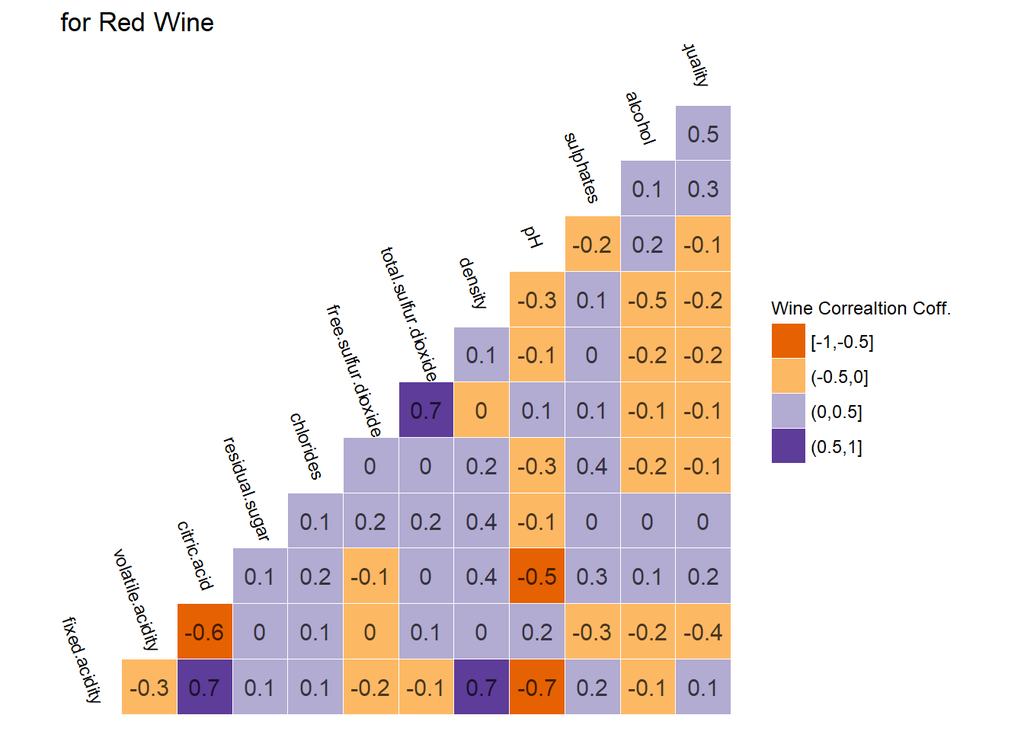

Not very strong correlation between the variables and quantity of wine, alcohol content and volatile acidity can be taken into consideration.

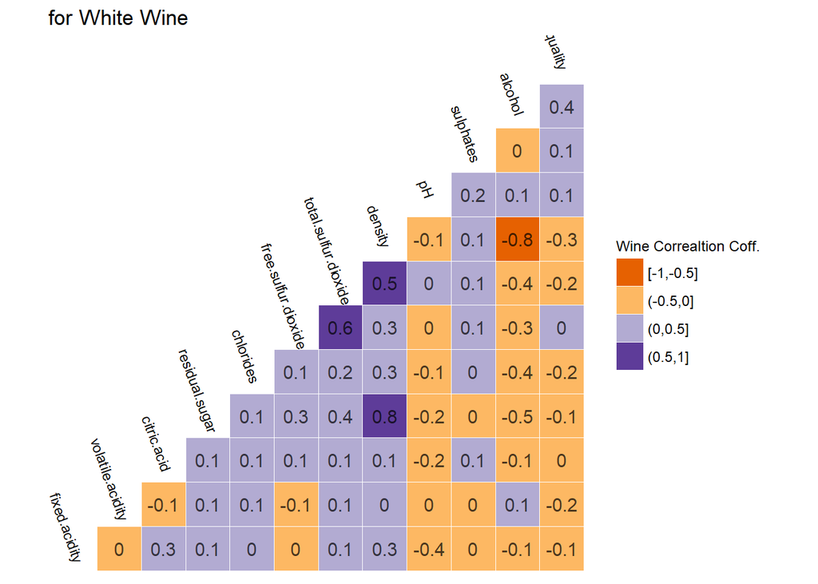

For white wine, only alcohol seems to be quality deciding factor.

## Final Plots and Summary

I chose these three plots to showcase the final summary of this data exploration

1)Quality and rating

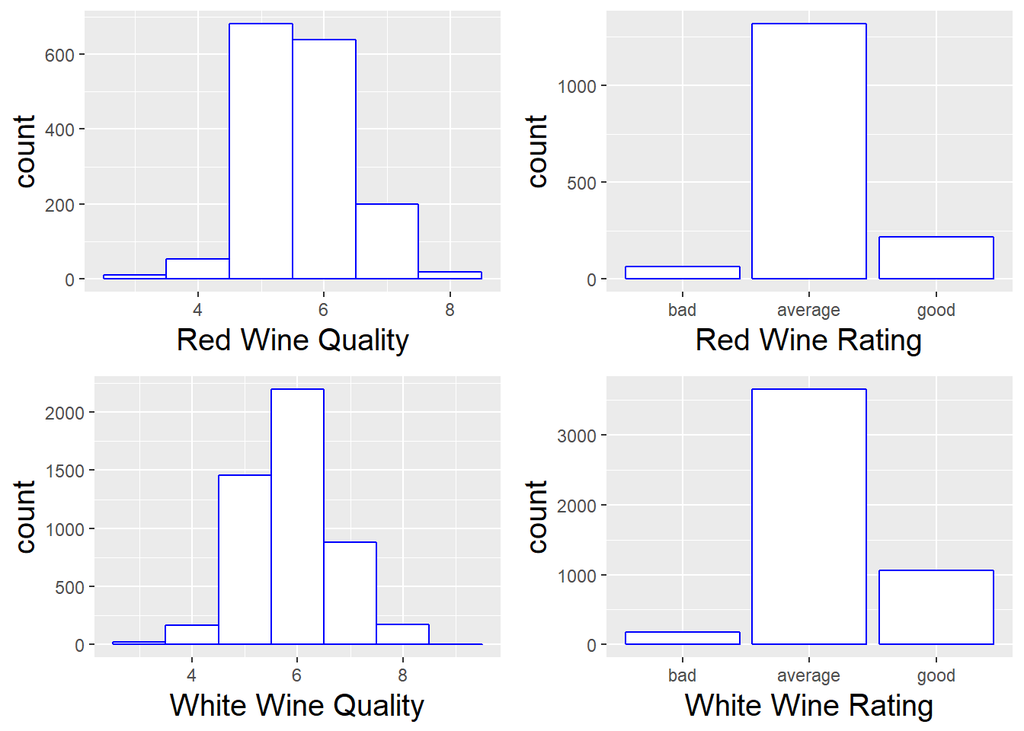

We have most of the avarage class wines in the data set, that could make the algorithm to predict only the avarage class with precision.

2. the residual sugar content for red and white wine -

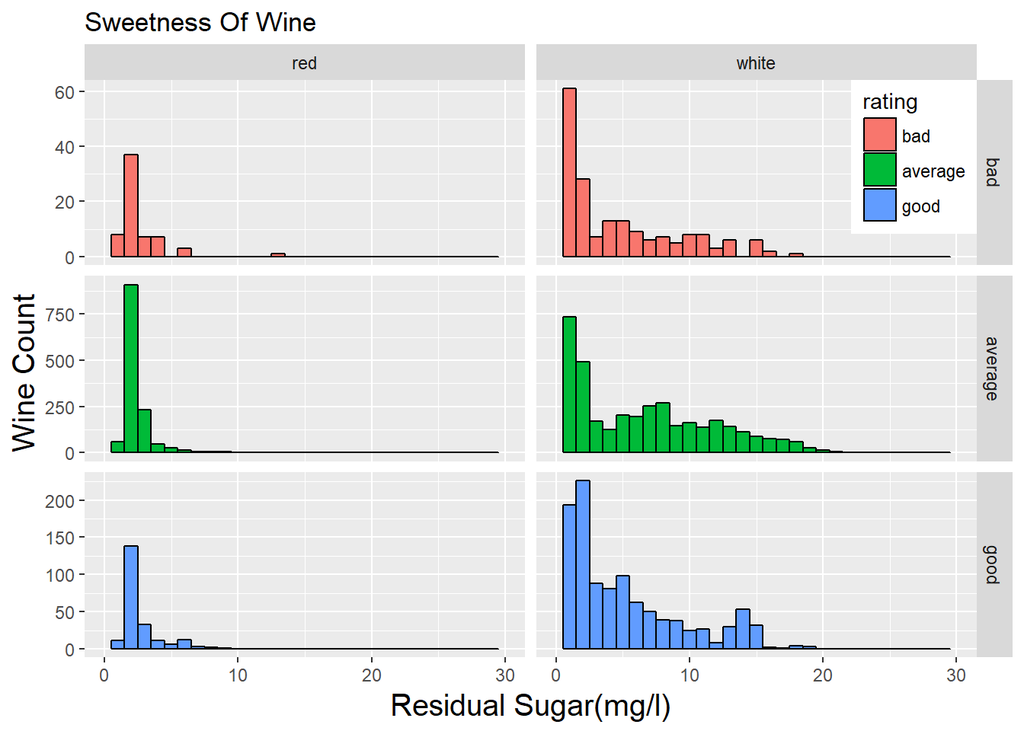

The above plot shows that white wine have sweeter varieties of wines than red wine.

3)exploring alcohol (% by volumn) and density (mg/l)

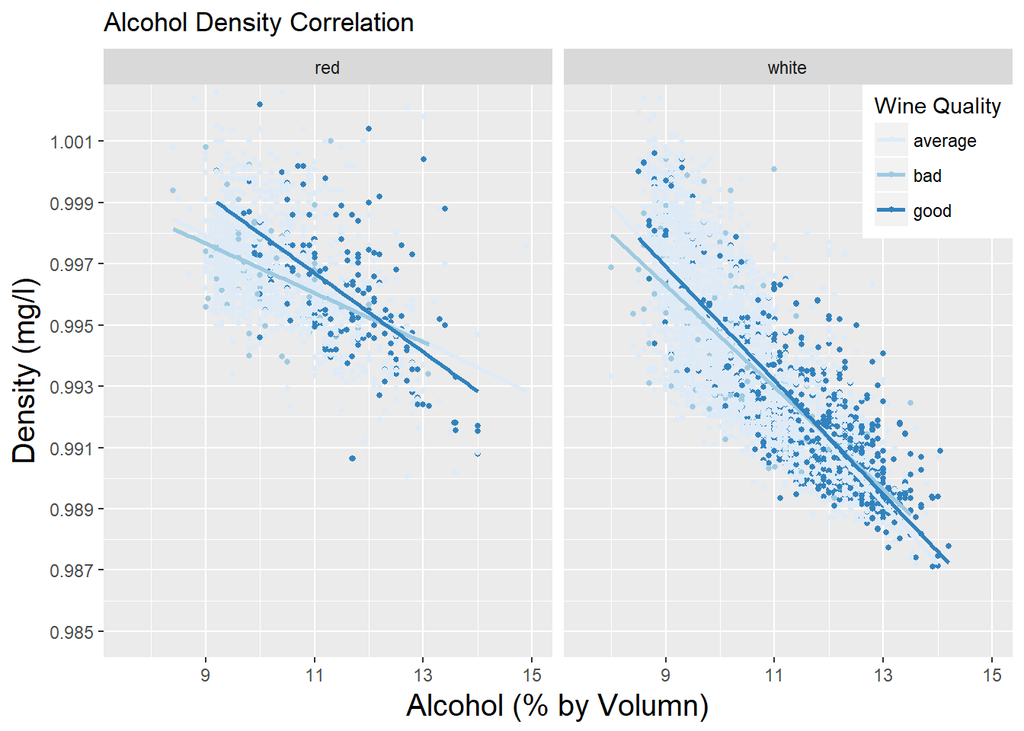

## Refection

Initial exploration of data showed that data is not balanced, “avarage” class wine contains most of the data compaired to “bad” and “good” class.

Further in the process, I tried to see the distribution of different variables through Univariate Plots. Mostly all are normally distributed. Main issue I came across was that there are a lot of outliers present in some variables. This could possiably be the bad data collected through error.

Give that there is not a strong co-relation between variables and quality of wine, it is kind of defficult to determine which variable could be tweaked to improve the quality of wine.

To overcome this issue, I would prefer to collect more data and then with feature engineering we could get the better algorithm to classify the wines.

Having said, this was a fun project to work on and learn along the way.